# Ford GoBike System Data

## by Nourhan Mohamed Ahmed

## Preliminary Wrangling

> This dataset includes information about individual rides made in a bike-sharing system covering the greater San Francisco Bay area.

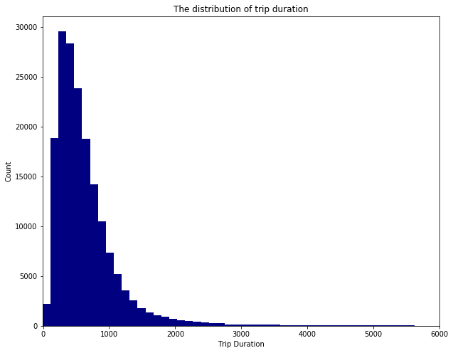

The duration distribution is right-skewed and there are outliers

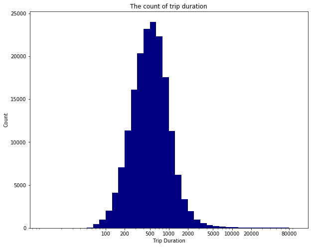

after applying log transformation it shows that trip duration is normal distribution

[figure not shown]

[figure not shown]

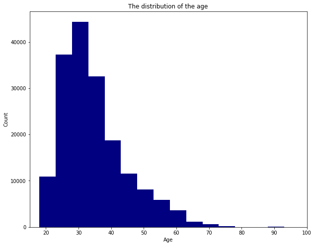

The distribution of the age is right-skewed and that's normal but there are outliers point 90 maybe it's normal but 140 definitely it's not normal.

[figure not shown]

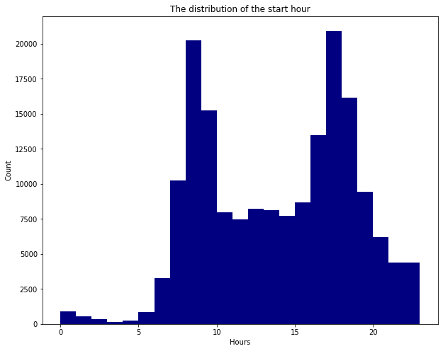

The plot shows that in point 13 it's a kind of symmetric That's because of early birds people and night owls people.

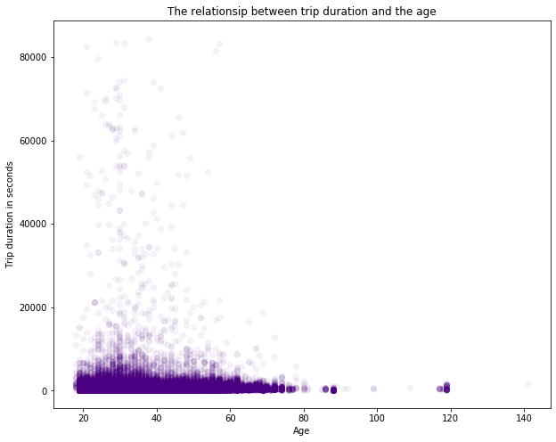

The trip duration decreases while the age increases as expected.

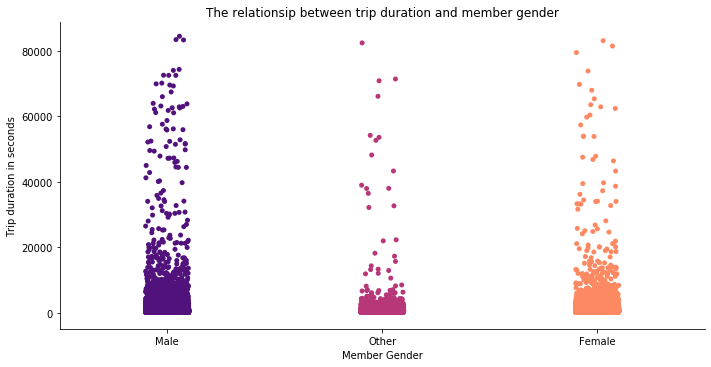

Males are the most gender but they all making a long trip duration.

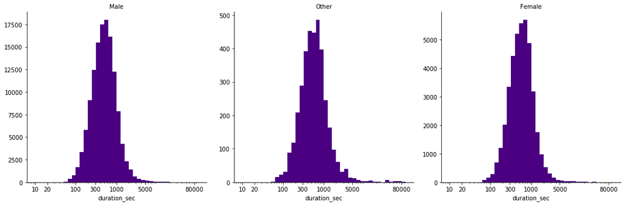

[figure not shown]

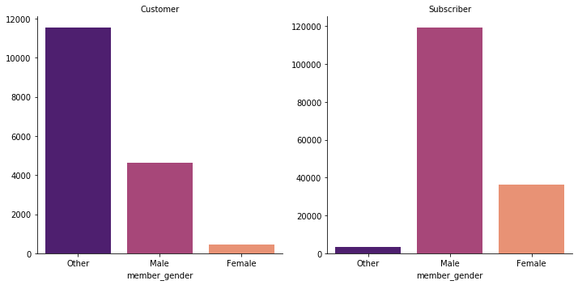

It seems that most of the subscriber are males, and most of the customer are other

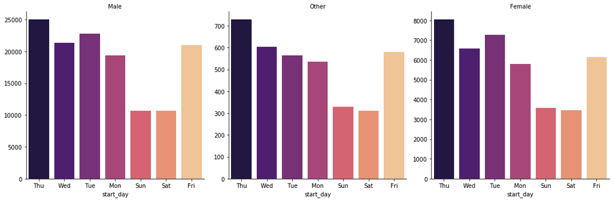

It seems that the proportion of the gender is the same for all the days.

and Thursday is the favorite for all genders.

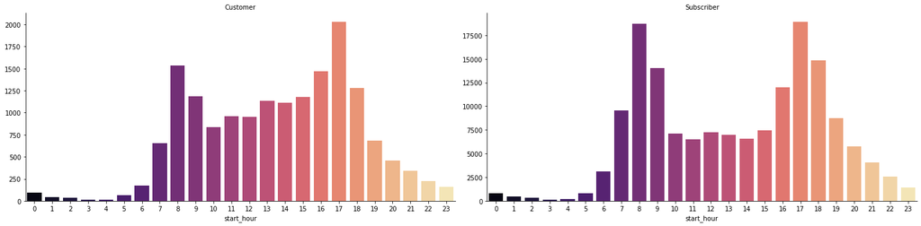

As we see there are two favourite hours at (8 am and 5 pm) and that's for all users.

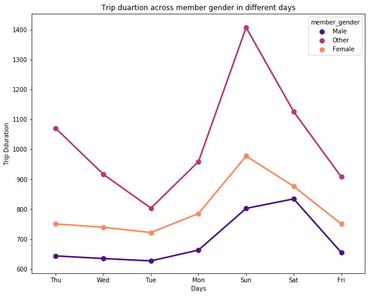

It seems that others have the longest trip duration in sunday and in general